```python
from IPython.display import YouTubeVideo,Image
```

```python
# 42:00, 土石流
YouTubeVideo("hU0c5ZUIXHE")
```

[video not shown]

# AD 536, 公元536年, [Wikipedia](https://en.wikipedia.org/wiki/536)

## Lecture for Energy Resources and Sustainable Civilization

## Events amid AD 536 and on, 大事記

1. 中國，太陽從這一年開始變得昏暗,在盛夏的八九月份竟然下起了雪和冰雹, 此後, 全球範圍經歷了長達10年的嚴寒天氣。
   - 公元535年，中國北部發生了大規模的乾旱並且日益嚴重，成千上萬的良田變得一片貧瘠，巨大的塵暴開始肆虐。公元535年11月到12月間，在南朝的首都南京大量黃塵從天而降。公元536年9月，中國的某些地區天降大雪和冰雹。帶來的影響在之後一百餘年才慢慢恢復。
   - 南北朝時期， (山西省通志, 東魏孝靜帝天平三年八月(9/15) (AD 536)，并肆涿建四州隕霜大饑四年春詔所在開倉賑恤)

```
  北朝的東魏和西魏互相攻伐，人口由3000萬下降到2000萬左右；
  南朝的梁則更是悲慘，536年前後還有人口1200萬，但由於神秘的霧霾導致各種資源短缺，在醞釀了12年後，「侯景之亂」爆發，
  人口銳減到一百多萬，史書形容「千里絕煙，人跡罕見，白骨成聚，如丘隴焉」。
                                          原文網址：https://kknews.cc/history/mj2ao3z.html
```

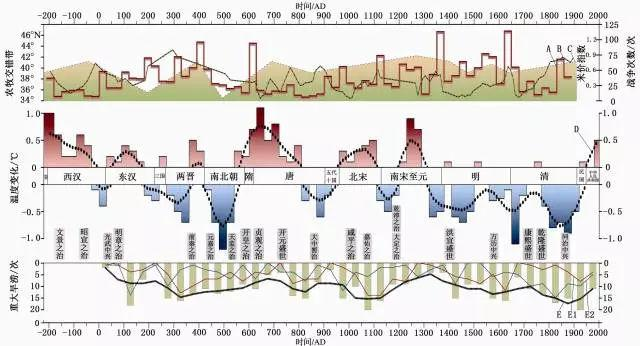

```python
Image("0.jpeg",width=300)
```

2. 歐洲,公元541~542年的一場黑死病使東羅馬帝國失去了近1/4的人口, (AD 565),

[figure not shown]

3. 中美洲,公元6世紀一場特大乾旱讓那裡的巨大城邦特奧蒂瓦肯瀕臨毀滅。
4. 愛爾蘭編年史紀錄:「公元536年到539年期間的麵包欠收。」之後數年「生計艱難」
5. 東羅馬歷史學家普羅科匹厄斯（Procopius）在書中記載：「太陽光芒有如月亮般黯淡，世界好像經歷一場無限期的日食，此後沒有人逃得過戰爭、瘟疫，或者其他致命災難的磨難。」歷史上著名的查士丁尼大瘟疫（Plague of Justinian）在5年後爆發，東羅馬帝國近半人口死亡。
6. 美國哥倫比亞大學Lamont-Doherty地球觀測室的阿伯特（Dallas Abbott）等研究學者認為，約1500年前的西元536年前後，歐洲曾經歷過一場飢荒，這場飢荒可能與著名的哈雷彗星有關 (每76年一次路過地球軌道)。

```
英國天文學家愛得蒙‧哈雷（Edmond Halley）檢視彗星記錄時，發現西元1531年、1607年和1682年的彗星似乎是同一顆，後精確認為真，成為第一顆確認有週期性

二千六百多年前，中國東周春秋時代的魯文公14年，西元前613年的時候， 「秋七月，有星北孛入於北斗」。
西元前240年，在《史記．始皇本記》中的記載是這樣的：「始皇七年，彗星先出東方，見北方；五月見西方，十六日。」
西方最早的記載，見於西元468和464年間，是由希臘人記錄下來的。
西元前164年10月，兩河流域上的古巴比倫人用當時的楔形文字刻在泥板上
西元前12年10月，新約聖經馬太福音記述的伯利恆之星了，東方三位占星博士朝著這顆彗星來到伯利恆，朝拜降生在馬槽內的聖嬰。
...
1986年，
下一次是2061-2062年，
```

## Researches

1. 研究人員在阿爾卑斯山鑽取了72米長的冰芯，超精確地分析了過去2000年大氣中自然和人為活動產生的物質對氣候環境的影響，判斷冰島火山在公元536年初的巨大噴發，可能是釀成這次災難的主要原因，該火山之後又於540年和547年再次大規模噴發。火山灰大量進入大氣層，遮蔽了太陽，導致536年夏天氣溫的下降，引發了整整持續十年的寒冷天氣，是過去2000多年來最寒冷的「黑暗世紀」，還有科學家對樹木年輪的分析也證實了這段時間氣溫的下降。
2. 2018年，專門鑽研世界中古史的哈佛大學教授麥可·麥考密克（Michael McCormick）與他的團隊經過研究，最終得出了一個學界認可的結論：公元536年還沒有被歐洲人發現的冰島，發生了接連不斷的火山大爆發，大量火山灰湧入大氣層，導致北半球的太陽黯淡無光，前後歷時達18個月。
3. 英國諾丁漢大學教授勒夫拉克（Christopher Loveluck） 指出，大規模的火山爆發產生巨量火山灰壟罩北半球，在缺乏陽光的情況下導致氣溫驟降，作物欠收，進而引發饑荒，這樣的災害持續到了西元542年，低溫、饑荒和鼠疫同時侵襲東羅馬帝國。勒夫拉克指出，火山爆發和542年的瘟疫導致了歐洲經濟停擺，直到575年才有復甦的跡象，因為用來冶煉銀的鉛礦再次出現，顯示出因經濟活動的發展，使用貨幣的需求自然浮現，歐洲經濟也在640至660年間快速成長、轉型。

```
原文網址：https://kknews.cc/history/mj2ao3z.html
        https://www.setn.com/news.aspx?newsid=875209
        https://news.ltn.com.tw/news/world/breakingnews/2619850
        https://www.ettoday.net/news/20131225/310046.htm
        https://en.wikipedia.org/wiki/Global_temperature_record
```

## 科學家是如何重構過去數萬年的氣溫呢？

**冰芯 (Ice core)**

冰芯 (Ice core)，是透過在冰川上進行鑽探並獲得的圓柱狀雪冰樣本，包含了長時間積累的降雪以及乾燥和濕潤沉積物質。這些物質保存了沉積時所記錄的氣候環境信息。

冰川是由固態降水(雪）長時間積累和演變而成的。在雪粒逐漸壓縮密集化並轉變成冰川冰的過程中，將雪粒層中的空隙封閉成氣泡。

南極和北極的冰芯記錄著過去的氣候環境變化。透過對這些冰芯的研究，已經揭示了地球過去 80 萬年來氣候與大氣中溫室氣體含量的變化情況。 同時記錄明顯的氣候突變特徵。 因此研究學者透過冰芯研究，重建了歷史時期的太陽活動變化和火山噴發事件的信息。

在20世紀70年代中後期，美國的 Thompson 等學者對秘魯 Quelccaya 冰帽進行了考察和冰芯鑽取工作。研究結果建立了近1500年的氣候變化記錄。 從此低緯度的冰芯研究和高緯度的南北極冰芯研究一樣重要。

自然存在的氧 ($\text{O}$) 主要有兩種 (化學上稱為同位素)，一是有八顆質子和八顆中子的 $\text{O}_{16}$，另一是有八顆質子和十顆中子的$\text{O}_{18}$。$\text{O}_{16}$的重量比 $\text{O}_{18}$ 輕且較常見，兩種氧同位素都能與兩顆氫原子合成水分子($\text{H}_2\text{)}$)。$\text{O}_{18}$與 $\text{O}_{16}$ 的比例在溫暖氣候時段會較高，因為有更多的能量去蒸發含 $\text{O}_{18}$ 較重的水份子，它們隨著大氣環流抵達極區並凝結成雪降下。在較冷的氣候裏，會有較少含較重O18的水份子能被蒸發，其中很多會在抵達極區前便凝結成雨或雪降下，能夠抵達極區的就更少了。因此，科學家從冰芯內的 $\text{O}_{18}$ 與 $\text{O}_{16}$ 的比例便可大約知道地球過去的氣溫情況。

有很多方法為冰芯定年。最直接的方法是數算 $\text{O}_{18}$ 與 $\text{O}_{16}$ 比例的年際變化(在夏季時稍高而在冬季較低）。另一個有用的方法是從其他氣候記錄中(例如樹木年輪和沉積記錄等)，辨認出一些特別的事件(例如火山爆發)，利用這些事件以校正冰芯記錄的時間尺度，從而重建出過去數萬年的氣溫時間序列。

1. Petit, J.R., D. Raynaud, C. Lorius, J. Jouzel, G. Delaygue, N.I. Barkov, and V.M. Kotlyakov. 2000: Historical isotopic temperature record from the Vostok ice core. In Trends: A Compendium of Data on Global Change. Carbon Dioxide Information Analysis Center, Oak Ridge National Laboratory, U.S. Department of Energy, Oak Ridge, Tenn., U.S.A. doi: 10.3334/CDIAC/cli.006
2. https://www.hko.gov.hk/tc/climate_change/faq/faq013.htm
3. CO2 data, https://www.ncei.noaa.gov/pub/data/paleo/icecore/antarctica/law/law2006-co2-noaa.txt

## 恐龍為何滅絕？

**凍死的? 或者 ...**

過去66,000,000年前， 流星撞地球，造成地球進入長期冬季低溫，恐龍因此滅跡. 但是幾天前的論文，提出了新的看法， 相撞產生大量的粉塵散步整個大氣層，造成光合作用無法作用長達兩年，這才是恐龍滅絕的原因：

[Cem Berk Senel et al., Chicxulub impact winter sustained by fine silicate dust, Nature Geoscience, 30, Oct, 2023](https://www.nature.com/articles/s41561-023-01290-4)

## NOAA Data

Data had been modified by chatGPT

One of important factor about Earth temperature is concentration of $\text{CO}_2$. Let us visualize the historic $\text{CO}_2$ data.

```python
import pandas as pd
import math

df=pd.read_csv('CO2.csv', sep=',',index_col=0, usecols=range(3))
```

```python
# get rid of " symbol
df[" ageCE"]=df[" ageCE"].apply(lambda x:x[2:-1])
df[" CO2"]=df[" CO2"].apply(lambda x:x[2:-1])
```

```python
# convert to float and rename the columns

df[" ageCE"] = df[' ageCE'].values.astype(float)
df[" CO2"] = df[' CO2'].values.astype(float)
df.rename(columns={' ageCE':'ageCE',' CO2':'CO2'},inplace=True)
```

```python
# Convert 'Value1' (ageCE) to integers using floor
df['ageCE'] = df['ageCE'].apply(lambda x: math.floor(float(x)))

# Remove duplicates and calculate the mean for each unique 'Value1' (ageCE)
df = df.groupby('ageCE')['CO2'].mean().reset_index()

# Print the resulting DataFrame
print(df)
```

```
     ageCE    CO2
0       13  276.7
1       29  277.9
2       56  277.4
3      104  277.5
4      136  278.1
..     ...    ...
188   2002  370.5
189   2003  372.8
190   2004  374.7
191   2005  376.7
192   2006  378.7

[193 rows x 2 columns]
```

```python
import plotly.express as px
```

```python
m=px.scatter(df,x='ageCE',y='CO2')
```

```python
display(m)
```

[interactive chart not shown]